# Dropout logistic regression

Anton Kalén

2021-09-19

## 0.1 Method

We fit all models with 4000 sampling iterations over 4 cores. If nothing else is specified, default weakly informative priors are used. Plots show 80% and 95% CI.

## 0.2 Full model

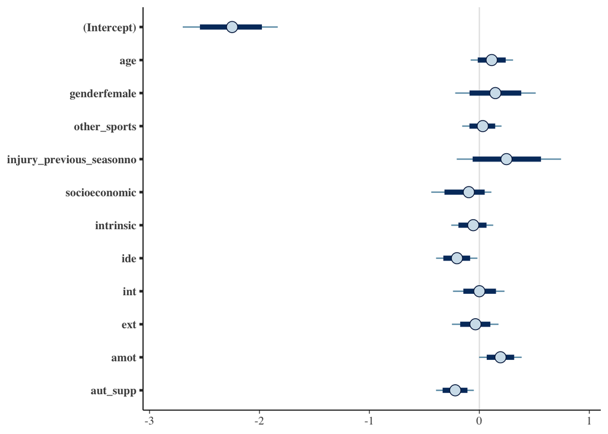

```r
full_model <- stan_glm(
  dropout ~ 1 +
    age +
    gender +
    other_sports +
    injury_previous_season +
    socioeconomic +
    intrinsic +
    ide +
    int +
    ext +
    amot +
    aut_supp,
  data = dropout_std,
  chains = 4,
  iter = 2000,
  cores = 4,
  family = binomial(link = "logit")
)

plot(full_model, prob = 0.8, prob_outer = .95)
```

```r
describe_posterior(full_model, ci = c(.89)) %>%
  insight::print_md()
```

Summary of Posterior Distribution

| Parameter | Median | 89% CI | pd | ROPE | % in ROPE | Rhat | ESS |
| --- | --- | --- | --- | --- | --- | --- | --- |
| (Intercept) | -2.25 | [-2.62, -1.92] | 100% | [-0.18, 0.18] | 0% | 1.000 | 5951.00 |
| age | 0.11 | [-0.05, 0.26] | 87.22% | [-0.18, 0.18] | 76.90% | 1.001 | 5732.00 |
| genderfemale | 0.15 | [-0.16, 0.43] | 78.65% | [-0.18, 0.18] | 56.93% | 0.999 | 5805.00 |
| other_sports | 0.03 | [-0.12, 0.17] | 63.22% | [-0.18, 0.18] | 97.74% | 1.000 | 5608.00 |
| injury_previous_seasonno | 0.25 | [-0.14, 0.63] | 85.47% | [-0.18, 0.18] | 38.38% | 1.000 | 6517.00 |
| socioeconomic | -0.10 | [-0.35, 0.09] | 77.68% | [-0.18, 0.18] | 72.32% | 1.001 | 3881.00 |
| intrinsic | -0.06 | [-0.22, 0.10] | 72.25% | [-0.18, 0.18] | 90.63% | 1.000 | 5122.00 |
| ide | -0.20 | [-0.35, -0.05] | 98.28% | [-0.18, 0.18] | 39.07% | 0.999 | 5811.00 |
| int | 1.68e-04 | [-0.18, 0.19] | 50.08% | [-0.18, 0.18] | 92.61% | 1.000 | 4788.00 |
| ext | -0.04 | [-0.20, 0.14] | 62.68% | [-0.18, 0.18] | 93.19% | 1.000 | 4856.00 |
| amot | 0.19 | [ 0.03, 0.34] | 97.22% | [-0.18, 0.18] | 45.17% | 1.000 | 5427.00 |
| aut_supp | -0.22 | [-0.36, -0.08] | 99.55% | [-0.18, 0.18] | 31.86% | 1.000 | 5461.00 |

## 0.3 Horseshoe prior

```r
# p <- 11
# n <- nrow(dropout_data)
# p0 <- 3 # prior guess for the number of relevant variables
# tau0 <- p0/(p-p0) * 1/sqrt(n)
# hs_prior <- hs(df=1, global_df=1, global_scale=tau0)
# t_prior <- student_t(df = 7, location = 0, scale = 2.5)
#
# hs_model <- update(full_model, prior = hs_prior)
#
# plot(hs_model, prob = 0.8, prob_outer = .95)
```

## 0.4 Projection predictive variable selection

Next, we use projection predictive variable selection to select relevant parameters. The selection is done using the [`projpred`](https://mc-stan.org/projpred/)-package, and is described in (Piironen, Paasiniemi, and Vehtari 2020; Piironen and Vehtari 2016).

Below we see the order of the variables (by importance):

```r
full_model_cvvs <- cv_varsel(full_model, method = "L1")
```

```
## [1] "Computing LOOs..."
##
## [1] "Performing the selection using all the data.."
## [1] "Done."
```

```r
solution_terms(full_model_cvvs)
```

```
##  [1] "amot"                   "aut_supp"               "ide"
##  [4] "intrinsic"              "age"                    "injury_previous_season"
##  [7] "gender"                 "other_sports"           "socioeconomic"
## [10] "ext"                    "int"
```

In the plot below, we can see an improvement in predictive performance going up to 3 predictors. More than 3 does not seem to improve the predictive performance.

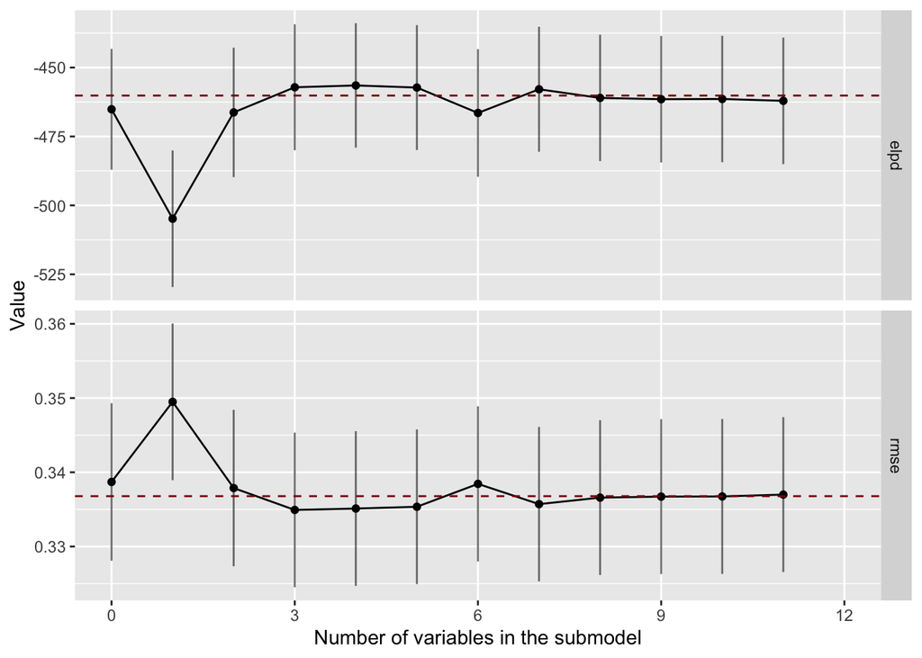

```r
plot(full_model_cvvs, stats = c('elpd', 'rmse'))
```

We confirm this by looking at the suggested number of parameters.

```r
(nv <- suggest_size(full_model_cvvs, alpha=0.95))
```

```
## [1] 3
```

Below we see the posterior estimates of the selected model.

```r
final_model <- stan_glm(
  dropout ~ 1 +
    amot +
    aut_supp +
    ide,
  data = dropout_std,
  chains = 4,
  iter = 2000,
  cores = 4,
  family = binomial(link = "logit")
)
bayestestR::describe_posterior(final_model, ci = c(.89)) %>%
  insight::print_md()
```

Summary of Posterior Distribution

| Parameter | Median | 89% CI | pd | ROPE | % in ROPE | Rhat | ESS |
| --- | --- | --- | --- | --- | --- | --- | --- |
| (Intercept) | -1.97 | [-2.12, -1.83] | 100% | [-0.18, 0.18] | 0% | 1.000 | 3999.00 |
| amot | 0.21 | [ 0.09, 0.32] | 99.83% | [-0.18, 0.18] | 35.67% | 1.000 | 4457.00 |
| aut_supp | -0.23 | [-0.37, -0.10] | 99.62% | [-0.18, 0.18] | 25.49% | 0.999 | 4297.00 |
| ide | -0.23 | [-0.38, -0.10] | 99.55% | [-0.18, 0.18] | 26.52% | 1.000 | 4298.00 |

```r
final_predict <- predict(final_model, dropout_std, type = "response")


final_predict_class <- factor(if_else(final_predict >= mean(as.integer(dropout_std$dropout) - 1), "dropout", "no dropout"))

caret::confusionMatrix(final_predict_class, dropout_std$dropout, positive = "dropout")
```

```
## Confusion Matrix and Statistics
##
##             Reference
## Prediction   no dropout dropout
##   no dropout        655      68
##   dropout           378      89
##
##                Accuracy : 0.6252
##                  95% CI : (0.597, 0.6528)
##     No Information Rate : 0.8681
##     P-Value [Acc > NIR] : 1
##
##                   Kappa : 0.1094
##
##  Mcnemar's Test P-Value : <2e-16
##
##             Sensitivity : 0.56688
##             Specificity : 0.63408
##          Pos Pred Value : 0.19058
##          Neg Pred Value : 0.90595
##              Prevalence : 0.13193
##          Detection Rate : 0.07479
##    Detection Prevalence : 0.39244
##       Balanced Accuracy : 0.60048
##
##        'Positive' Class : dropout
##
```

Confusion matrix (classification table) for the full model. Using the proportion of dropouts in the original data as cuttoff.

```r
full_predict <- predict(full_model, dropout_std, type = "response")


full_predict_class <- factor(if_else(full_predict >= mean(as.integer(dropout_std$dropout) - 1), "dropout", "no dropout"))

caret::confusionMatrix(full_predict_class, dropout_std$dropout, positive = "dropout")
```

```
## Confusion Matrix and Statistics
##
##             Reference
## Prediction   no dropout dropout
##   no dropout        664      65
##   dropout           369      92
##
##                Accuracy : 0.6353
##                  95% CI : (0.6072, 0.6627)
##     No Information Rate : 0.8681
##     P-Value [Acc > NIR] : 1
##
##                   Kappa : 0.1256
##
##  Mcnemar's Test P-Value : <2e-16
##
##             Sensitivity : 0.58599
##             Specificity : 0.64279
##          Pos Pred Value : 0.19957
##          Neg Pred Value : 0.91084
##              Prevalence : 0.13193
##          Detection Rate : 0.07731
##    Detection Prevalence : 0.38739
##       Balanced Accuracy : 0.61439
##
##        'Positive' Class : dropout
##
```

Piironen, Juho, Markus Paasiniemi, and Aki Vehtari. 2020. “Projective Inference in High-Dimensional Problems: Prediction and Feature Selection.” *Electronic Journal of Statistics* 14 (1). https://doi.org/10.1214/20-ejs1711.

Piironen, Juho, and Aki Vehtari. 2016. “Comparison of Bayesian Predictive Methods for Model Selection.” *Statistics and Computing* 27 (3): 711–35. https://doi.org/10.1007/s11222-016-9649-y.